# Chemical portraits of cancer proteomes (2016, 2017)

This vignette runs the code to make selected plots from the following papers:

> Dick JM. 2016. Proteomic indicators of oxidation and hydration state in colorectal cancer. *PeerJ* **4**: e2238. doi: 10.7717/peerj.2238

> Dick JM. 2017. Chemical composition and the potential for proteomic transformation in cancer, hypoxia, and hyperosmotic stress. *PeerJ* **5**: e3421. doi: 10.7717/peerj.3421

This vignette was compiled on 2025-05-20 with **JMDplots** 1.2.22 and **canprot** 2.0.0.

```r
library(JMDplots)
```

## Microbial proteins in colorectal cancer (2016 Figure 4)

Stability fields represent the ranges of oxygen fugacity and water activity where a protein with the mean amino acid composition from the labeled microbial species has a higher per-residue affinity (lower Gibbs energy) of formation than the others. Blue and red shading designate microbes relatively enriched in samples from healthy donors and cancer patients, respectively. Plot (E) is a composite figure in which the intensity of shading corresponds to the number of overlapping healthy- or cancer-enriched microbes in the preceding diagrams

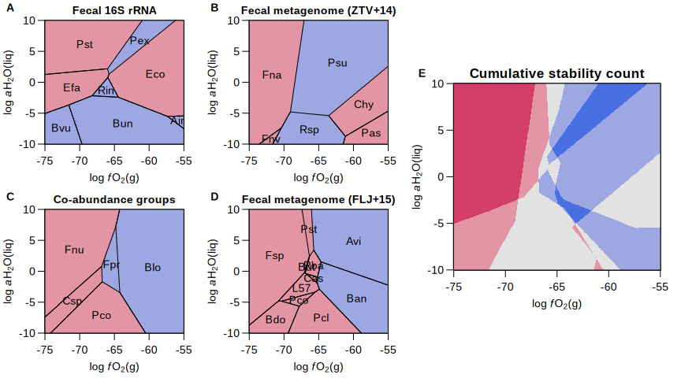

**Data sources:** **A**. Wang et al. (2012). **B**. Zeller et al. (2014). **C**. Candela et al. (2014). **D**. Feng et al. (2015).

## Potential diagrams: Pancreatic cancer (2017 Figure S3 and 3E)

The potential diagrams show the weighted rank difference of chemical affinities between up- and down-expressed proteins in each dataset. Groups of datasets are considered that have similar chemical features, i.e. changes in *Z*<sub>C</sub> and *n*H<sub>2</sub>O.

Here we make plots for datasets for pancreatic cancer having a mean difference of *n*H<sub>2</sub>O that is > 0.01 and a small *Z*<sub>C</sub>, as judged by the *p*-value and common language effect size (CLES). Red and blue correspond to greater potential for formation of the up- and down-expressed proteins, respectively; the line of equipotential is shown in white:

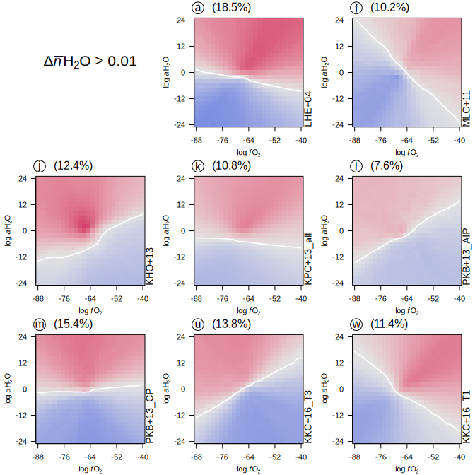

```r
gpresult <- groupplots("pancreatic_H2O_up", res = 25)
```

Now let’s make a merged diagram. The red-white-blue shading is computed from the mean of the previous diagrams. The black lines show the median and quartiles for the *y*-positions of the equipotential lines in the previous diagrams. The second plot shows effective values of Eh (redox potential) as a function of the same variables (oxygen fugacity and water activity) (see 2016 Figure 6I).

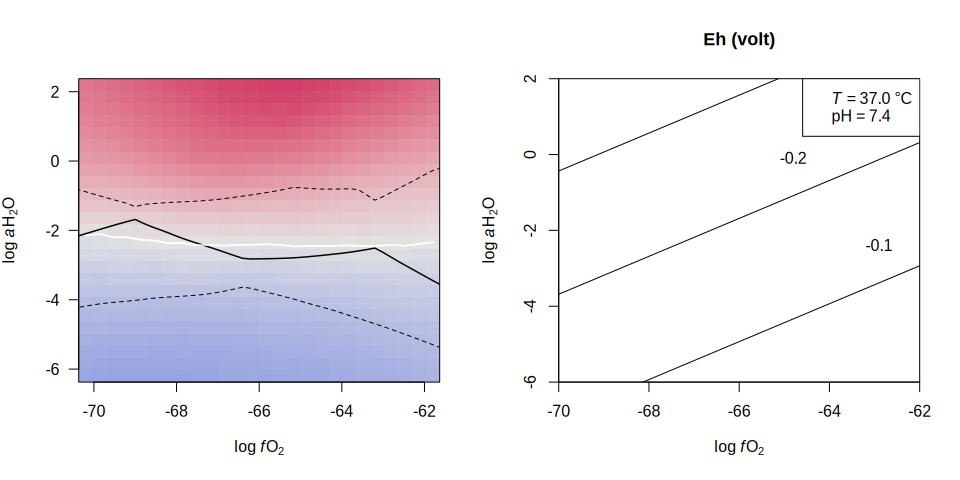

```r
par(mfrow = c(1, 2))
mergedplot(gpresult, res = 25)
Ehplot(xlim = c(-70, -62), ylim = c(-6, 2), dy = 0.1)
```

**Data sources:** Lu et al. (2004), McKinney et al. (2011), Kawahara et al. (2013), Kosanam et al. (2013), Paulo et al. (2013), Kuo et al. (2016).

## Basis species comparison (2017 Figure S1)

These plots show projections of elemental composition of proteins made using two sets of basis species. Using the `CHNOS` basis species (CO<sub>2</sub>, NH<sub>3</sub>, H<sub>2</sub>S, H<sub>2</sub>O, O<sub>2</sub>), the plots show that *n*H<sub>2</sub>O and *n*O<sub>2</sub>, i.e. the number of H<sub>2</sub>O and O<sub>2</sub> in the formation per residue of the proteins from basis species, are both moderately correlated with *Z*<sub>C</sub> (average oxidation state of carbon). Using the `QEC` basis species (glutamine, glutamic acid, cysteine, H<sub>2</sub>O, O<sub>2</sub>), we find that *n*O<sub>2</sub> is strongly correlated with *Z*<sub>C</sub>, but *n*H<sub>2</sub>O shows very little correlation. Accordingly, the `QEC` basis more clearly exposes two chemical variables – oxidation state and hydration state – in proteomic data.

Here we define some labels used in the plot.

```r
QEClab <- CHNOSZ::syslab(c("glutamine", "glutamic acid", "cysteine", "H2O", "O2"))
CHNOSlab <- CHNOSZ::syslab(c("CO2", "NH3", "H2S", "H2O", "O2"))
```

Next, get the amino acid compositions of all proteins in the UniProt human proteome and calculate the protein formulas and *Z*<sub>C</sub>. Note that *Z*<sub>C</sub> is a sum of elemental ratios and is independent of the choice of basis species.

```r
aa <- get("human.base", canprot)
protein.formula <- CHNOSZ::protein.formula(aa)
ZC <- CHNOSZ::ZC(protein.formula)
```

Now set up the figure and plot the per-residue elemental compositions of the proteins projected into different sets of basis species.

```r
par(mfrow = c(2, 2))
par(mar = c(4, 4, 2.5, 1))
par(cex = 1.1)
par(mgp = c(2.5, 1, 0))
for(basis in c("QEC", "CHNOS")) {
  CHNOSZ::basis(basis)
  protein.basis <- CHNOSZ::protein.basis(aa)
  protein.length <- CHNOSZ::protein.length(aa)
  residue.basis <- protein.basis / protein.length
  smoothScatter(ZC, residue.basis[, "O2"], xlab = cplab$Zc, ylab = cplab$nO2)
  smoothScatter(ZC, residue.basis[, "H2O"], xlab = cplab$Zc, ylab = cplab$nH2O)
  if(basis=="QEC") mtext(QEClab, outer = TRUE, cex = 1.2, line = -1.5)
  if(basis=="CHNOS") mtext(CHNOSlab, outer = TRUE, cex = 1.2, line = -15)
}
```

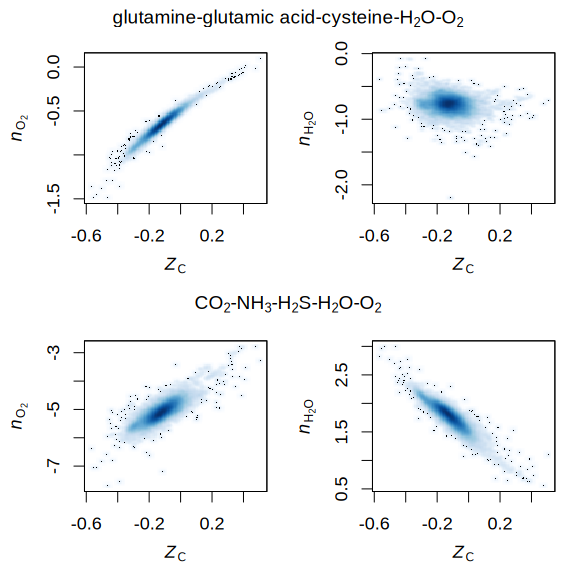

## Chemical analysis of differentially expressed proteins (2017 Figures 1 and 2)

*Updates to these datasets and plots were made for a **paper in 2021**.*

For individual vignettes including data references, see the files in `system.file("extdata/cpcp", package = "JMDplots")`.

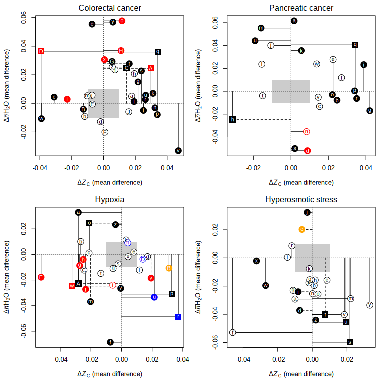

## References

Candela M, Turroni S, Biagi E, Carbonero F, Rampelli S, Fiorentini C, Brigidi P. 2014. Inflammation and colorectal cancer, when microbiota-host mutualism breaks. *World Journal of Gastroenterology* **20**(4): 908–922. doi: 10.3748/wjg.v20.i4.908

Feng Q, Liang S, Jia H, Stadlmayr A, Tang L, Lan Z, Zhang D, Xia H, Xu X, Jie Z, et al. 2015. Gut microbiome development along the colorectal adenoma-carcinoma sequence. *Nature Communications* **6**: 6528. doi: 10.1038/ncomms7528

Kawahara T, Hotta N, Ozawa Y, Kato S, Kano K, Yokoyama Y, Nagino M, Takahashi T, Yanagisawa K. 2013. Quantitative proteomic profiling identifies DPYSL3 as pancreatic ductal adenocarcinoma-associated molecule that regulates cell adhesion and migration by stabilization of focal adhesion complex. *PLOS One* **8**(12): e79654. doi: 10.1371/journal.pone.0079654

Kosanam H, Prassas I, Chrystoja CC, Soleas I, Chan A, Dimitromanolakis A, Blasutig IM, Rückert F, Gruetzmann R, Pilarsky C, et al. 2013. Laminin, gamma 2 (LAMC2): A promising new putative pancreatic cancer biomarker identified by proteomic analysis of pancreatic adenocarcinoma tissues. *Molecular & Cellular Proteomics* **12**(10): 2820–2832. doi: 10.1074/mcp.M112.023507

Kuo K-K, Kuo C-J, Chiu C-Y, Liang S-S, Huang C-H, Chi S-W, Tsai K-B, Chen C-Y, Hsi E, Cheng K-H, et al. 2016. Quantitative proteomic analysis of differentially expressed protein profiles involved in pancreatic ductal adenocarcinoma. *Pancreas* **45**(1): 71–83. doi: 10.1097/MPA.0000000000000388

Lu Z, Hu L, Evers S, Chen J, Shen Y. 2004. Differential expression profiling of human pancreatic adenocarcinoma and healthy pancreatic tissue. *Proteomics* **4**(12): 3975–3988. doi: 10.1002/pmic.200300863

McKinney KQ, Lee Y-Y, Choi H-S, Groseclose G, Iannitti DA, Martinie JB, Russo MW, Lundgren DH, Han DK, Bonkovsky HL, et al. 2011. Discovery of putative pancreatic cancer biomarkers using subcellular proteomics. *Journal of Proteomics* **74**(1): 79–88. doi: 10.1016/j.jprot.2010.08.006

Paulo JA, Kadiyala V, Brizard S, Banks PA, Steen H, Conwell DL. 2013. A proteomic comparison of formalin-fixed paraffin-embedded pancreatic tissue from autoimmune pancreatitis, chronic pancreatitis, and pancreatic cancer. *Journal of the Pancreas* **14**(4): 405–414. doi: 10.6092/1590-8577/1508

Wang T, Cai G, Qiu Y, Fei N, Zhang M, Pang X, Jia W, Cai S, Zhao L. 2012. Structural segregation of gut microbiota between colorectal cancer patients and healthy volunteers. *The ISME Journal* **6**(2): 320–329. doi: 10.1038/ismej.2011.109

Zeller G, Tap J, Voigt AY, Sunagawa S, Kultima JR, Costea PI, Amiot A, Böhm J, Brunetti F, Habermann N, et al. 2014. Potential of fecal microbiota for early-stage detection of colorectal cancer. *Molecular Systems Biology* **10**(11): 766. doi: 10.15252/msb.20145645